# Project: Wrangling and Analysing twitter archive - WeRateDogs.

1. Introduction
2. Data Gathering:
   - WeRateDogs Twitter Archive
   - Tweet Image Predictions
   - Additional data from Twitter API
   - Assessing data
   - Cleaning Data
   - Storing Data

## Introduction

WeRateDogs is a Twitter account that rates people's dogs with a humorous comment about the dog. This project required us to collect three individual datasets via different methods, assess and clean each dataset and finally draw insights from our analysis.

## Data Gathering: WeRateDogs Twitter Archive

This dataset -a csv file- was downloaded manually, uploaded and read into a pandas dataframe.

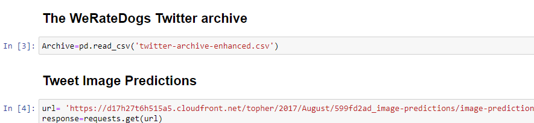

## Data Gathering: Tweet Image Predictions

This dataset was downloaded programmatically using Requests library and [this url](https://d17h27t6h515a5.cloudfront.net/topher/2017/August/599fd2ad_image-predictions/image-predictions.tsv). I imported the request library and saved the url of the file as a variable for simplicity. The file was then requested from its server using 'requests.get'. The downloaded data was then written out to a local file.

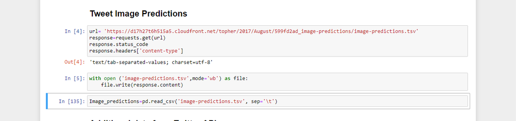

## Data Gathering: Additional data from Twitter API

For this last piece of data, three custom functions were created to gather each tweet's favorite count, retweet count and followers count and store them in a file called tweet_json.txt.This file was then read into a pandas dataframe named 'TweetApi'.

- *Note: The JSON file used was that provided by the Udacity team*

## Assessing Data

After gathering all three pieces of data namely archive,image predictions and TweetApi respectively , they were assessed visually and programatically for quality and tidiness issues. The datasets were assessed programatically using pandas functions such as pd.head, pd.info,etc. An excel spreadsheet was used to further assess each dataset. Nine quality and six tidiness issues were detected at the end of the assessment.

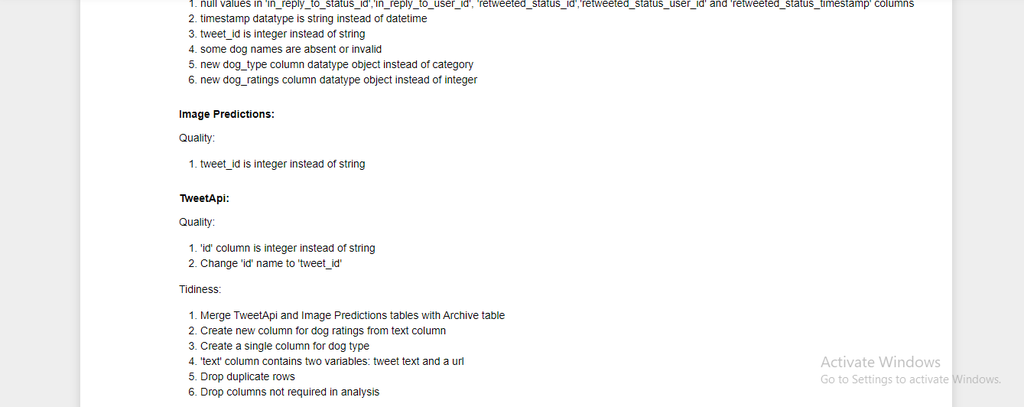

## Cleaning Data

All issues documented during assessment were cleaned in this section. A copy of each original data was made and the data was cleaned using the define-code-test framework.

### Missing Data:

Because there was no way to fill the missing values due to absence of information, the columns with numerous missing values were dropped.

### Tidiness:

All three datasets were merged on a common column, 'tweet_id' after which all documented tidiness issues were addressed.

### Quality:

This was the last issue to be addressed. As stated in assessing data above, there were nine quality issues

## Storing Data

The cleaned master dataframe was stored in a CSV file.

After storage, the wrangled data was then explored using visualisation to obtain insights.